# Regional infectivity of COVID-19

```r
library(tidyverse)
devtools::load_all("~/Git/uk-covid-datatools/")
```

```
#> Loading ukcovidtools
```

```r
# devtools::install_github("terminological/uk-covid-datatools")
# library(ukcovidtools)
devtools::load_all("~/Git/standard-print-output/")
```

```
#> Loading standardPrintOutput
#> Warning: replacing previous import 'ggplot2::theme_grey' by
#> 'huxtable::theme_grey' when loading 'standardPrintOutput'
#> Warning: replacing previous import 'dplyr::add_rownames' by
#> 'huxtable::add_rownames' when loading 'standardPrintOutput'
#>
```

```r
library(rgdal)
```

```r
library(ggplot2)
library(ggspatial)
library(rgeos)
library(maptools)
library(lubridate)
library(patchwork)
library(sp)

ggplot2::theme_set(standardPrintOutput::defaultFigureLayout())
```

```
#> Registering fonts with R
```

```r
source("./lockdown-impact-data.R")
```

```
#> Warning in summary.lm(lmResult): essentially perfect fit: summary may be
#> unreliable
#> Warning in summary.lm(object, ...): essentially perfect fit: summary may be
#> unreliable
```

## Serial interval estimation from the literature:

```r
SItable1 %>% group_by(`Reference`) %>% standardPrintOutput::saveTable("~/Dropbox/covid19/lockdown-impact/Table1_serialIntervals", defaultFontSize = 8, colWidths=c(4.5,2,2,0.5,1))
```

| Reference | Mean SI (95% CrI) days | Std SI (95% CrI) days | N | Population |
| --- | --- | --- | --- | --- |
| Bi, Q. et al. Epidemiology and Transmission of COVID-19 in Shenzhen China: Analysis of 391 cases and 1,286 of their close contacts. Infectious Diseases (except HIV/AIDS) (2020) doi:10.1101/2020.03.03.… | 6.3 (5.2-7.6) | 4.2 (3.1-5.3) | 48 | Shenzhen |
| Cereda, D. et al. The early phase of the COVID-19 outbreak in Lombardy, Italy. arXiv [q-bio.PE] (2020) | 6.6 (0.7-19) | unk (unk-unk) | 90 | Italy |
| Ganyani, T. et al. Estimating the generation interval for COVID-19 based on symptom onset data. Infectious Diseases (except HIV/AIDS) (2020) doi:10.1101/2020.03.05.20031815 | 3.95 (-4.47-12.51) | 4.24 (4.03-4.95) | 45 | Taijin |
|  | 5.21 (-3.35-13.94) | 4.32 (4.06-5.58) | 54 | Singapore |
| Li, Q. et al. Early Transmission Dynamics in Wuhan, China, of Novel Coronavirus-Infected Pneumonia. N. Engl. J. Med. (2020) doi:10.1056/NEJMoa2001316 | 7.5 (5.3-19) | 3.4 (unk-unk) | 16 | Wuhan |
| Nishiura, H., Linton, N. M. & Akhmetzhanov, A. R. Serial interval of novel coronavirus (COVID-19) infections. Int. J. Infect. Dis. (2020) doi:10.1016/j.ijid.2020.02.060 | 4.7 (3.7-6) | 2.3 (1.6-3.5) | 28 | SE Asia |
| Tindale, L. et al. Transmission interval estimates suggest pre-symptomatic spread of COVID-19. Epidemiology (2020) doi:10.1101/2020.03.03.20029983 | 4.22 (3.43-5.01) | 0.4 (unk-unk) | 135 | Taijin |
|  | 4.56 (2.69-6.42) | 0.95 (unk-unk) | 93 | Singapore |
| Zhanwei Du et al. Serial Interval of COVID-19 among Publicly Reported Confirmed Cases. Emerging Infectious Disease journal 26, (2020) | 3.96 (3.53-4.39) | 4.75 (4.46-5.07) | 468 | China |

## Used serial intervals

```r
#  wtSIs is the serial intervals
tdp = function(x,y,z) sprintf("%1.2f (%1.2f - %1.2f)", x ,y, z)
paste0("Serial interval mean plus 95% credible interval: ",tdp(wtSIs$mean_si, wtSIs$min_mean_si, wtSIs$max_mean_si))
```

```
#> [1] "Serial interval mean plus 95% credible interval: 4.56 (2.54 - 7.36)"
```

```r
paste0("Serial interval standard deviation plus 95% credible interval: ",tdp(wtSIs$std_si, wtSIs$min_std_si, wtSIs$max_std_si))
```

```
#> [1] "Serial interval standard deviation plus 95% credible interval: 4.53 (4.17 - 5.05)"
```

## Significant dates in epididemic UK

https://en.wikipedia.org/wiki/2020_coronavirus_pandemic_in_the_United_Kingdom

- Surveillance testing: https://www.gov.uk/government/news/new-surveillance-system-for-early-detection-of-covid-19: 2020-02-26
- Sport fixtures cancelled: 2020-03-13
- Tests only for inpatients: https://www.gov.uk/government/publications/wuhan-novel-coronavirus-initial-investigation-of-possible-cases/investigation-and-initial-clinical-management-of-possible-cases-of-wuhan-novel-coronavirus-wn-cov-infection: 2020-03-13
- Voluntary self isolation of any symptoms & vunerable people: https://www.gov.uk/government/publications/covid-19-guidance-on-social-distancing-and-for-vulnerable-people: 2020-03-16
- Non essential travel worldwide banned: https://www.gov.uk/guidance/travel-advice-novel-coronavirus#history: 2020-03-19
- School closures: https://www.gov.uk/government/publications/closure-of-educational-settings-information-for-parents-and-carers#history: 2020-03-19
- Full lockdown: https://www.gov.uk/government/publications/full-guidance-on-staying-at-home-and-away-from-others - 2020-03-23

```r
glimpse(keyDates)
```

```
#> Observations: 4
#> Variables: 3
#> $ date  <date> 2020-03-16, 2020-03-23, 2020-03-27, 2020-04-09
#> $ event <chr> "Social isolation of vulnerable", "Social distancing", "One SI …
#> $ label <chr> "2020-03-16: \nSocial isolation of vulnerable", "2020-03-23: \n…
```

### UK coutries

The R(t) in the different countries of the UK in figure 1. This has fallen from a high initial level (2-3) to just over 1 by 2020-04-07 in all regions.

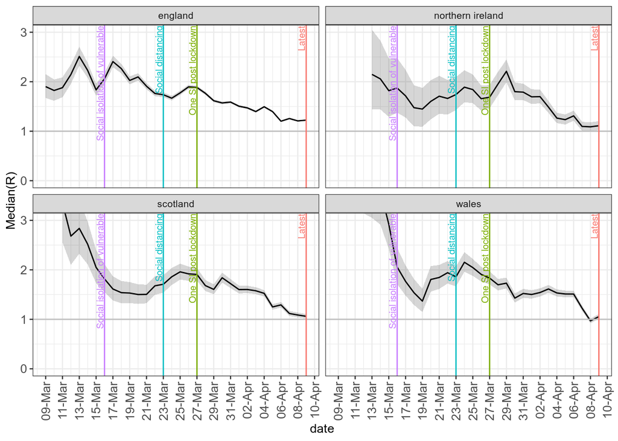

```r
r0ukregionalplot = ggplot(ts$r0UKRegional, aes(x=date, y=`Median(R)`, ymin=`Quantile.0.025(R)`, ymax=`Quantile.0.975(R)`))+
  geom_ribbon(alpha=0.2)+geom_line()+
  geom_hline(yintercept = 1, colour="grey75")+

  coord_cartesian(ylim=c(0, 3))+
  geom_vline(aes(xintercept=date,colour=event),data=keyDates, show.legend = FALSE)+
  ggrepel::geom_text_repel(
          aes(x=date, y=Inf, colour=event, label=event),data=keyDates, hjust=0,vjust=1, angle=90, show.legend = FALSE,box.padding=0.05,inherit.aes = FALSE,
          size=(10/ggplot2:::.pt/(96/72)))+
  scale_x_date(date_breaks="2 day", date_labels = "%d-%b")+
  theme(axis.text.x=element_text(angle = 90, vjust =0.5))+
  facet_wrap(vars(uk_region))

r0ukregionalplot %>% standardPrintOutput::saveHalfPageFigure("~/Dropbox/covid19/lockdown-impact/Fig1_ukRegionRt")
```

The rate of change of R(t) in the different countries of the UK. This shows the viral reproduction has been decelerating since 2020-03-31 in all regions.

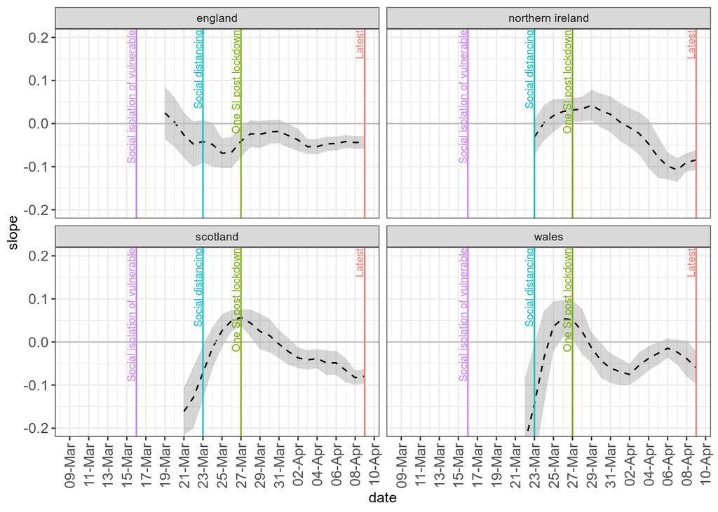

```r
deltaR0ukregionalplot = ggplot(ts$r0UKRegional, aes(x=date, y=slope, ymin=slopeLowerCi, ymax=slopeUpperCi))+
  geom_ribbon(alpha=0.2)+geom_line(linetype="dashed")+
  geom_hline(yintercept = 0, colour="grey75")+
  coord_cartesian(ylim=c(-0.2, 0.2))+
  geom_vline(aes(xintercept=date,colour=event),data=keyDates, show.legend = FALSE)+
  ggrepel::geom_text_repel(
          aes(x=date, y=Inf, colour=event, label=event),data=keyDates, hjust=0,vjust=1, angle=90, show.legend = FALSE,box.padding=0.05,inherit.aes = FALSE,
          size=(10/ggplot2:::.pt/(96/72)))+
  scale_x_date(date_breaks="2 day", date_labels = "%d-%b")+
  theme(axis.text.x=element_text(angle = 90, vjust =0.5))+
  facet_wrap(vars(uk_region))

deltaR0ukregionalplot %>% standardPrintOutput::saveHalfPageFigure("~/Dropbox/covid19/lockdown-impact/Fig5_deltaUkRegionRt")



```

## NHS regions

The same analysis as above but looking at NHS regions. there is some evidence that viral replication is different in different areas.

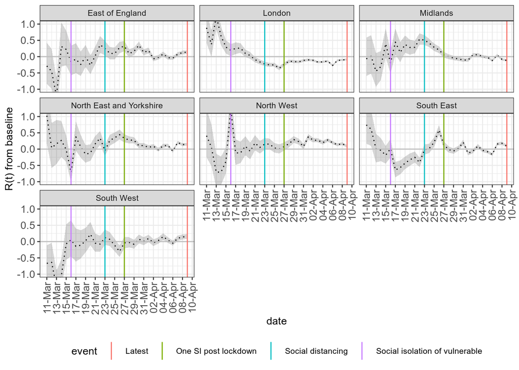

```r
tmp = ts$r0UKRegional %>% filter(uk_region == "england") %>% select(date,baseline=`Median(R)`)
englandnhsFromBaseline = ts$r0EnglandNHS %>% left_join(tmp, by="date") %>% mutate(
  `R(t) from baseline`=`Median(R)`-baseline, ymin=`Quantile.0.025(R)`-baseline, ymax=`Quantile.0.975(R)`-baseline
)

#glimpse(ts$tidyEnglandNHS)
englandnhsplot = ggplot(englandnhsFromBaseline, aes(x=date, y=`R(t) from baseline`, ymin=ymin, ymax=ymax))+
  geom_ribbon(alpha=0.2)+geom_line(linetype="dotted")+
  geom_hline(yintercept = 0, colour="grey75")+
  facet_wrap(vars(england_nhs_region)) +
  standardPrintOutput::narrowAndTall()+
  coord_cartesian(ylim=c(-1,1))+
  geom_vline(aes(xintercept=date,colour=event),data=keyDates)+
  scale_x_date(date_breaks="2 day", date_labels = "%d-%b")+
  theme(axis.text.x=element_text(angle = 90, vjust = 0.5))

englandnhsplot %>% standardPrintOutput::saveHalfPageFigure("~/Dropbox/covid19/lockdown-impact/Fig2-englandNHSRt")
```

Significance tests:

```r
englandnhsFromBaselineSignificance = englandnhsFromBaseline %>%
  filter(date > as.Date("2020-03-27")) %>%
  group_by(england_nhs_region) %>%
  group_modify(function(d,g,...) {
    res = t.test(d$`Median(R)`,d$baseline,paired = TRUE)
    return(tibble(
      `R(t) effect size` = sprintf("%1.2f", res$estimate),
      `95% CI` = sprintf("(%1.2f; %1.2f)", res$conf.int[1], res$conf.int[2]),
      pValue = ifelse(res$p.value < 0.001, "<0.001", sprintf("%1.3f", res$p.value))
    ))
  }) %>% rename(`England NHS region`=england_nhs_region)
englandnhsFromBaselineSignificance %>% standardPrintOutput::saveTable("~/Dropbox/covid19/lockdown-impact/Table2-regionalSignificance", defaultFontSize = 8)
```

| England NHS region | R(t) effect size | 95% CI | pValue |
| --- | --- | --- | --- |
| East of England | 0.09 | (0.02; 0.16) | 0.014 |
| London | -0.14 | (-0.17; -0.11) | <0.001 |
| Midlands | -0.04 | (-0.08; 0.00) | 0.057 |
| North East and Yorkshire | 0.12 | (0.06; 0.18) | <0.001 |
| North West | 0.21 | (0.16; 0.26) | <0.001 |
| South East | 0.02 | (-0.06; 0.09) | 0.647 |
| South West | 0.05 | (-0.00; 0.10) | 0.059 |

## Unitary Authority Timeseries

The same analysis demonstrating R(t) but on a smaller regional level, plotted on a map at various time points Create static maps

```r
data("UKCovidMaps")

# https://github.com/tidyverse/ggplot2/issues/3391
# some issues joining tibble onto sf - which

r0shapes = UKCovidMaps$reportingRegions %>%
  # fill in missing dates to prevent the map having disappearing / reappearing regions
  crossing(tibble(date=unique(ts$r0CombinedUK$date))) %>%
  left_join(keyDates, by="date") %>%
  left_join(
    ts$r0CombinedUK,
    by=c("code","date"), suffix=c("",".dup")) %>%
  mutate(ago=difftime(date,lubridate::now(),units="days")) %>%
  sf::st_as_sf()
defaultR0Map = function(data) {
  return(
    ggplot(data)+
    geom_sf(aes(fill=`Median(R)`))+
    scale_fill_gradient2(
      low="green",
      mid="white",
      high="red",
      midpoint=0,
      trans="log",
      na.value = "grey80",
      limits=c(0.2,5),
      breaks=c(0.2,0.5,1,2,5),
      labels=c("<0.2","0.5","1","2",">5"),
      oob=scales::squish)+
    standardPrintOutput::narrowAndTall()+
    standardPrintOutput::mapTheme()
  )
}


defaultDeltaR0Map = function(data) {
  return(
    ggplot(data)+
    geom_sf(aes(fill=slope))+
    scale_fill_gradient2(
      low="cyan",
      mid="white",
      high="magenta",
      midpoint=0,
      na.value = "grey80",
      limits=c(-0.5,0.5),
      breaks=c(-0.5,-0.25,0,0.25,0.5),
      labels=c("<-0.5","-0.25","0","0.25",">0.5"),
      oob=scales::squish)+
    standardPrintOutput::narrowAndTall()+
    standardPrintOutput::mapTheme()
  )
}
```

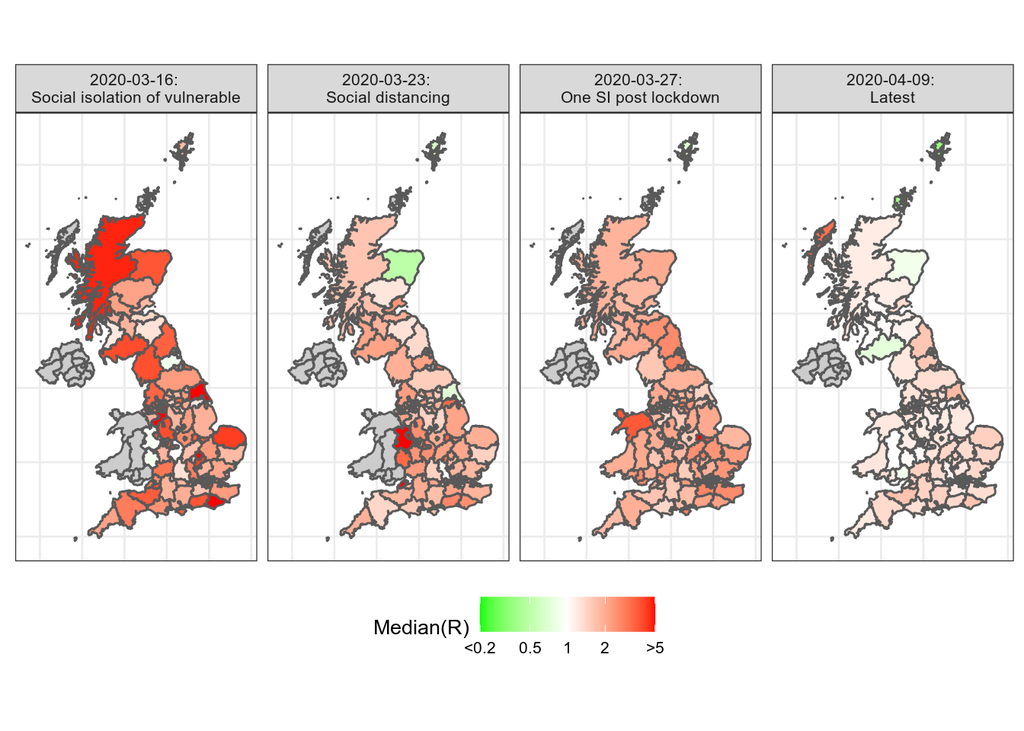

```r
ukwide =
  defaultR0Map(r0shapes %>% filter(!is.na(label)))+
  facet_wrap(vars(label), nrow = 1)
ukwide %>% standardPrintOutput::saveHalfPageFigure("~/Dropbox/covid19/lockdown-impact/Fig3_englandMap")
```

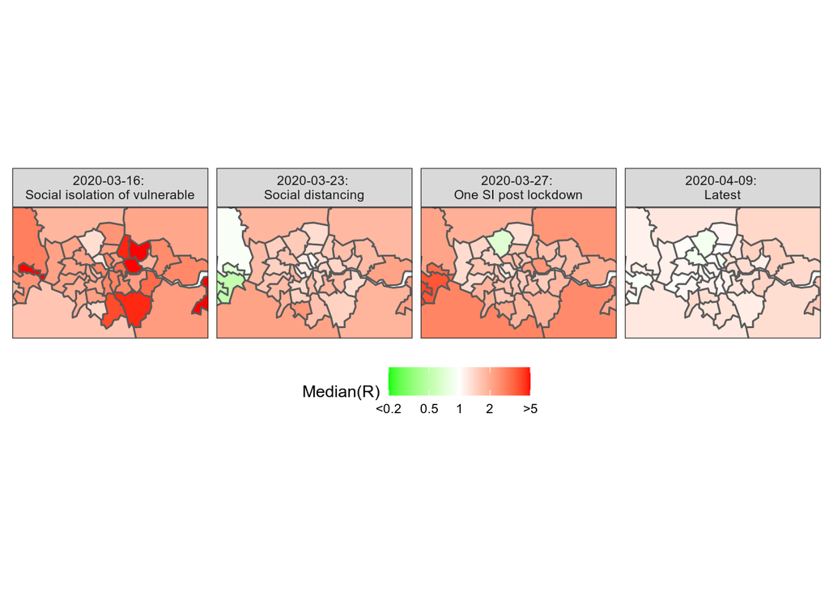

```r
london = ukwide + coord_sf(crs = 4326,xlim = c(-0.7, 0.5), ylim = c(51.25, 51.75), expand = FALSE) + standardPrintOutput::mapTheme()
london %>% standardPrintOutput::saveThirdPageFigure("~/Dropbox/covid19/lockdown-impact/Fig4_londonMap")
```

```r
# birmingham = ukwide + coord_sf(crs = 4326,xlim = c(-2.3, -1.5), ylim = c(52.25, 52.75), expand = FALSE) + standardPrintOutput::mapTheme()
# birmingham %>% standardPrintOutput::saveThirdPageFigure("~/Dropbox/covid19/lockdown-impact/Fig4_birminghamMap")
```

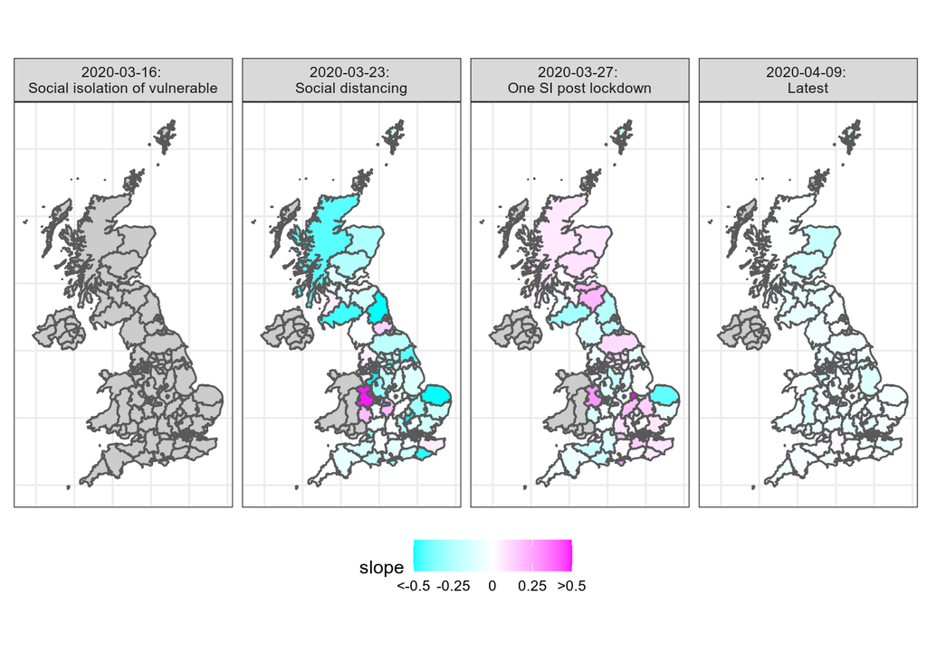

```r
ukwideDelta =
  defaultDeltaR0Map(r0shapes %>% filter(!is.na(label)))+
  facet_wrap(vars(label), nrow = 1)
ukwideDelta %>% standardPrintOutput::saveHalfPageFigure("~/Dropbox/covid19/lockdown-impact/Fig6_englandMapDelta")
```

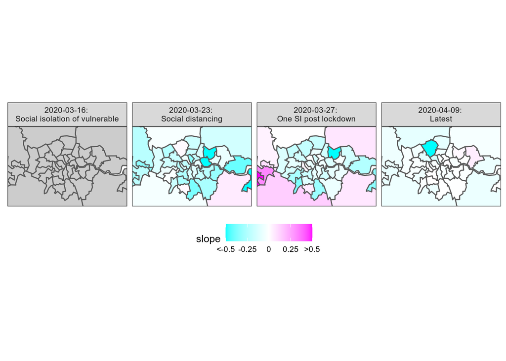

```r
londonDelta = ukwideDelta + coord_sf(crs = 4326,xlim = c(-0.7, 0.5), ylim = c(51.25, 51.75), expand = FALSE) + standardPrintOutput::mapTheme()
londonDelta %>% standardPrintOutput::saveThirdPageFigure("~/Dropbox/covid19/lockdown-impact/Fig7_londonMapDelta")
```

```r
# birminghamDelta = ukwideDelta + coord_sf(crs = 4326,xlim = c(-2.3, -1.5), ylim = c(52.25, 52.75), expand = FALSE) + standardPrintOutput::mapTheme()
# birminghamDelta %>% standardPrintOutput::saveThirdPageFigure("~/Dropbox/covid19/lockdown-impact/Fig7_birminghamMapDelta")
```

## Create and save animated map

Animated maps are viewable:

- https://github.com/terminological/uk-covid-datatools/blob/master/vignettes/UK_Rt_over_time.gif

```r
dates = tibble(date1=as.Date(min(r0shapes$date):max(r0shapes$date),origin=as.Date("1970-01-01")))
barAnim = ggplot(dates,aes(xmax=date1+1,xmin=date1))+
  geom_rect(ymin=0,ymax=1) +
  ylim(c(0,1))+
  geom_vline(aes(xintercept=date,colour=event),data=keyDates,size=4,show.legend = FALSE)+
  # ggrepel::geom_text_repel(
  #   aes(x=date, y=1.25, colour=event, label=event),data=keyDates, hjust=0.5,vjust=0, show.legend = FALSE,box.padding=0.05,inherit.aes = FALSE,
  #         size=(10/ggplot2:::.pt/(96/72)))+
  theme(
    axis.text.y = element_blank(),
    axis.ticks.y = element_blank(),
    panel.grid.major.y = element_blank(),
    panel.grid.minor.y = element_blank(),
    axis.title.x = element_blank()
  )+
  coord_cartesian(ylim = c(0, 1), clip = 'off')+
  gganimate::transition_time(date1)

timeGif = gganimate::animate(barAnim, renderer=gganimate::magick_renderer(), width=800, height=60)


ukwideAnim =
  defaultR0Map(r0shapes)+
  guides(fill="none")+labs(subtitle="A")+
  gganimate::transition_time(date)

londonAnim =
  defaultR0Map(r0shapes)+
  coord_sf(crs = 4326,xlim = c(-0.7, 0.5), ylim = c(51.25, 51.75), expand = FALSE) +
  standardPrintOutput::mapTheme()+labs(subtitle="C")+
  gganimate::transition_time(date)

ukwideDeltaAnim =
  defaultDeltaR0Map(r0shapes)+
  guides(fill="none")+labs(subtitle="B")+
  gganimate::transition_time(date)

londonDeltaAnim =
  defaultDeltaR0Map(r0shapes)+
  coord_sf(crs = 4326,xlim = c(-0.7, 0.5), ylim = c(51.25, 51.75), expand = FALSE) +
  standardPrintOutput::mapTheme()+labs(subtitle="D")+
  gganimate::transition_time(date)

ukWideGif = gganimate::animate(ukwideAnim, renderer=gganimate::magick_renderer(), width=400, height=800)
londonGif = gganimate::animate(londonAnim, renderer=gganimate::magick_renderer(), width=400,height=300)
ukWideDeltaGif = gganimate::animate(ukwideDeltaAnim, renderer=gganimate::magick_renderer(), width=400, height=800)
londonDeltaGif = gganimate::animate(londonDeltaAnim, renderer=gganimate::magick_renderer(), width=400,height=300)

layoutGifs = function(i) {
  magick::image_append(c(
  magick::image_append(c(ukWideGif[i], ukWideDeltaGif[i])),
  magick::image_append(c(londonGif[i], londonDeltaGif[i])),
  timeGif[i]), stack=TRUE)
}

new_gif <- layoutGifs(1)
for(i in 2:100){
  combined <- layoutGifs(i)
  new_gif <- c(new_gif, combined)
}

#gganimate::anim_save("~/Git/uk-covid-datatools/vignettes/UK_Rt_over_time.gif",new_gif)
magick::image_write_gif(new_gif,path="~/Git/uk-covid-datatools/vignettes/UK_Rt_over_time.gif")
# ggplot(r0shapes, aes(x=date,y=`Median(R)`,colour=code))+geom_line(alpha=0.2,show.legend = FALSE)
```

```r
# rateOfChangeDist = ggplot(rateOfChange, aes(x=slope))+geom_density()+geom_rug()+geom_vline(xintercept = 0, colour="blue")+coord_cartesian(xlim=c(-0.5,0.5))
#
# ukRateOfChange = ggplot(rateOfChangeUKregion, aes(x=uk_region,y=slope,fill=slope))+
#   scale_fill_gradient2(
#     low="cyan",
#     mid="white",
#     high="magenta",
#     midpoint=0,
#     #trans="log",
#     na.value = "grey80",
#     limits=c(-1,1),
#     breaks=c(-1,-0.5,0,0.5,1),
#     labels=c("<-1","-0.5","0","0.5",">1")
#     ) +
#   geom_bar(stat="identity", colour="black")+geom_errorbar(aes(ymin=slopeLowerCi,ymax=slopeUpperCi), width=0.2)
#
# (ukwideRateOfChange + londonRateofChange  + ukRateOfChange + rateOfChangeDist + plot_annotation(tag_levels = 'A')  + plot_layout(nrow = 2, guides="collect")) %>% standardPrintOutput::saveHalfPageFigure("~/Dropbox/covid19/lockdown-impact/Fig4_RateOfChangeMap")
#
```

```r
# rateOfChange %>% ungroup() %>% filter(slopeLowerCi > 0) %>% arrange(desc(slope)) %>% head(5) %>% mutate(`95% CI` = sprintf("%1.2f; %1.2f",slopeLowerCi,slopeUpperCi)) %>% select(`Unitary authority`=name,`dR/dt`=slope, `95% CI` ,`R^2`=r_squared) %>% standardPrintOutput::saveTable("~/Dropbox/covid19/lockdown-impact/Table2_Top5UnitaryAuthoritiesByDeltaR_t")
```

```r
# rateOfChange %>% ungroup() %>% filter(slopeUpperCi < 0) %>% arrange(slope) %>% head(5) %>% mutate(`95% CI` = sprintf("%1.2f; %1.2f",slopeLowerCi,slopeUpperCi)) %>% select(`Unitary authority`=name,`dR/dt`=slope, `95% CI` ,`R^2`=r_squared) %>% standardPrintOutput::saveTable("~/Dropbox/covid19/lockdown-impact/Table3_Bottom5UnitaryAuthoritiesByDeltaR_t")
```

```r
# tmpDeltaR0timeseries =
#
# rateOfChangeShapes = UKCovidMaps$reportingRegions %>%
#   crossing(tibble(date=unique(tmpDeltaR0timeseries$date))) %>%
#   left_join(tmpDeltaR0timeseries, by=c("code","date")) %>%
#   sf::st_as_sf()
#
# ukwideRateOfChange = ggplot(rateOfChangeShapes)+
#   geom_sf(aes(fill=slope))+
#   scale_fill_gradient2(
#     low="cyan",
#     mid="white",
#     high="magenta",
#     midpoint=0,
#     trans="pseudo_log",
#     na.value = "grey80",
#     limits=c(-1,1),
#
#     breaks=c(-1,-0.5,0,0.5,1),
#     labels=c("<-1","-0.5","0","0.5",">1")
#     )+
#   standardPrintOutput::mapTheme()
#
# anim5 = ukwideRateOfChange + guides(fill="none")+#labs(title = 'Date: {frame_time}')+
#   gganimate::transition_time(date)
# gif5 = gganimate::animate(anim5, renderer=gganimate::magick_renderer(), width=400, height=800)
#
# anim6 = ukwideRateOfChange + coord_sf(crs = 4326,xlim = c(-0.7, 0.5), ylim = c(51.25, 51.75), expand = FALSE)+
#   gganimate::transition_time(date)
# gif6 = gganimate::animate(anim6, renderer=gganimate::magick_renderer(), duration = 10, fps=10, width=400, height=300)
```

```r
# dates = tibble(date1=as.Date(min(rateOfChangeShapes$date):max(rateOfChangeShapes$date),origin=as.Date("1970-01-01")))
# barAnim = ggplot(dates,aes(xmax=date1+1,xmin=date1))+
#   geom_rect(ymin=0,ymax=1) +
#   ylim(c(0,1))+
#   geom_vline(aes(xintercept=date,colour=event),data=keyDates,size=4,show.legend = FALSE)+
#   # ggrepel::geom_text_repel(
#   #   aes(x=date, y=1.25, colour=event, label=event),data=keyDates, hjust=0.5,vjust=0, show.legend = FALSE,box.padding=0.05,inherit.aes = FALSE,
#   #         size=(10/ggplot2:::.pt/(96/72)))+
#   theme(
#     axis.text.y = element_blank(),
#     axis.ticks.y = element_blank(),
#     panel.grid.major.y = element_blank(),
#     panel.grid.minor.y = element_blank(),
#     axis.title.x = element_blank()
#   )+
#   coord_cartesian(ylim = c(0, 1), clip = 'off')+
#   gganimate::transition_time(date1)
#
# timeGif = gganimate::animate(barAnim, renderer=gganimate::magick_renderer(), width=800, height=60)
```

```r
# ukRateOfChange = ggplot(deltaR0Regionaltimeseries, aes(x=uk_region,y=slope,fill=slope))+
#   scale_fill_gradient2(
#     low="cyan",
#     mid="white",
#     high="magenta",
#     midpoint=0,
#     #trans="log",
#     na.value = "grey80",
#     limits=c(-0.5,0.5),
#     breaks=c(-0.5,-0.25,0,0.25,0.5),
#     labels=c("<-0.5","-0.25","0","0.25",">0.5")
#     ) + geom_bar(stat="identity", colour="black")+geom_errorbar(aes(ymin=slopeLowerCi,ymax=slopeUpperCi), width=0.2)+
#   coord_cartesian(ylim=c(-0.25,0.25))#+
#   #labs(title = 'Date: {frame_time}')
#
# anim3 = ukRateOfChange+gganimate::transition_time(date)
# gif3 = gganimate::animate(anim3, renderer=gganimate::magick_renderer(), width=400, height = 300)
# #gganimate::anim_save("~/Git/uk-covid-datatools/vignettes/delta_Rt_by_uk_region_over_time.gif",gif)
#
# rateOfChangeDist = ggplot(deltaR0timeseries %>% filter(!is.na(slope)), aes(x=slope))+geom_density()+geom_rug()+geom_vline(xintercept = 0, colour="blue")+coord_cartesian(xlim=c(-0.5,0.5))+labs(title = " ")
# anim4 = rateOfChangeDist+gganimate::transition_time(date)
# gif4 = gganimate::animate(anim4, renderer=gganimate::magick_renderer(), width=400, height = 200)
#
# new_gif <- magick::image_append(c(
#       magick::image_append(c(
#         gif5[1],
#         magick::image_append(c(
#           gif3[1],
#           gif4[1],
#           gif6[1]
#         ),stack=TRUE)
#       )),
#       timeGif[1]
# ),stack=TRUE)
# for(i in 2:100){
#   combined <- magick::image_append(c(
#       magick::image_append(c(
#         gif5[i],
#         magick::image_append(c(
#           gif3[i],
#           gif4[i],
#           gif6[i]
#         ),stack=TRUE)
#       )),
#       timeGif[i]
# ),stack=TRUE)
#
#   new_gif <- c(new_gif, combined)
# }
#
# magick::image_write_gif(new_gif,path="~/Git/uk-covid-datatools/vignettes/delta_Rt_over_time.gif")
#gganimate::anim_save("~/Git/uk-covid-datatools/vignettes/delta_Rt_over_time.gif",new_gif)
#gganimate::anim_save("~/Git/uk-covid-datatools/vignettes/delta_Rt_distribution_over_time.gif",gif)
```

```r
# tmp = tempfile("google",fileext = ".pdf")
# pdf = "https://www.gstatic.com/covid19/mobility/2020-03-29_GB_Mobility_Report_en.pdf"
# download.file(pdf,tmp)
```

```r
# pdfExtract = pdftools::pdf_text(tmp)
# pdfExtract = pdfExtract[4:length(pdfExtract)-1]
# pdfExtract[[1]] %>% stringr::str_split("\n")
```